# Hantavirus Clinical Study Report

REDCap Data Analysis — Cohort Summary & Individual Patient Profiles

Author

WHO Global Clinical Platform

Published

August 16, 2026

# Contributing Sites & Investigators

**Contributing Sites & Investigators**

| Country | Site ID | Investigators |
| --- | --- | --- |
| 🇫🇷 France | 140001 | F-Xavier Lescure APHP |
| 🇪🇸 Spain | 140002 | Octavio Arce Garcia, Francisco Javier Membrillo de Novales, Tatiana Mata Forte Hospital Central de la Defensa “Gomez Ulla” |
| 🇳🇱 Netherlands | 140003 | Hetty Jolink Leiden University Medical Center |
| 🇫🇷 France | 140004 | Michael Thy Université Paris Cité, AP-HP |
| 🇳🇱 Netherlands | 140005 | Loek Smits Radboudumc |
| 🇨🇭 Switzerland | 140006 | Walter Zingg University Hospital Zurich |
| 🇳🇱 Netherlands | 140007 | Sacha de Stoppelaar AmsterdamUMC |
| 🇿🇦 South Africa | 140008 | Robyn Holgate, Evan Shoul University of the Witwatersrand, Mediclinic Southern Africa |
| 🇬🇧 United Kingdom | 140009 | Peter Moss St Helena Health Directorate |
| 🇨🇦 Canada | 140010 | Adrianna Gunton Island Health |

# Overview

**Note**

**Study:** Hantavirus (Andes virus) clinical surveillance **Data source:** REDCap longitudinal CRF **Report date:** 16 August 2026 **Patients enrolled:** 10 **Total REDCap records:** 636

10

Patients

8M / 2F

Sex

55.5

Mean Age (yrs)

10

Hospitalised

385

Tests Performed

286

Positive Tests

6

Received Antivirals

4

ICU Admitted

2

Invasive Ventilation

# Clinical Timeline

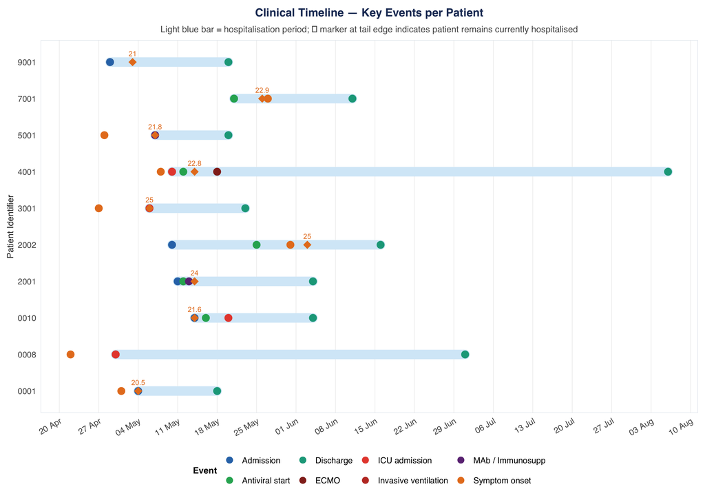

## Table 1 — Baseline & Clinical Characteristics

Baseline & Clinical Characteristics

| **Characteristic** | **Overall (N = 10)** **N = 10**<sup>1</sup> |
| --- | --- |
| Demographics |  |
| Sex |  |
| Female | 2 (20%) |
| Male | 8 (80%) |
| Age (years) | 60.4 (41.2–69.5) |
| BMI (kg/m²) | 26.4 (25.4–28.7) |
| Admitted | 10 (100%) |
| Healthcare Worker | 1 (10%) |
| Symptoms at Admission |  |
| Fever | 6 (60%) |
| Fatigue | 6 (60%) |
| Weakness | 6 (60%) |
| Myalgia | 4 (40%) |
| Headache | 4 (40%) |
| Dyspnoea | 3 (30%) |
| Diarrhoea | 2 (20%) |
| Haemorrhage | 0 (0%) |
| Comorbidities |  |
| Hypertension | 5 (50%) |
| Chronic Pulmonary | 1 (10%) |
| Malignancy | 5 (50%) |
| Obesity | 1 (10%) |
| Diabetes | 2 (20%) |
| Complications |  |
| Any Complication | 7 (70%) |
| Anaemia | 6 (60%) |
| Acute Renal Failure | 2 (20%) |
| Pleural Effusion | 2 (20%) |
| ARDS | 2 (20%) |
| Shock | 2 (20%) |
| Treatment & Severity |  |
| Received Antiviral | 6 (60%) |
| Received MAb / IVIG | 3 (30%) |
| Received Corticosteroid | 5 (50%) |
| ICU Admission | 4 (40%) |
| Invasive Ventilation | 2 (20%) |
| Virology |  |
| Lowest Ct (any specimen) | 22.8 (21.6–24.0) |
| Lowest Ct (blood/serum) | 22.8 (21.6–24.0) |

<sup>1</sup> n (%); Median (Q1–Q3)

# 1. Demographics & Enrolment

**Patient Demographics**

| PIN | Enrolment | Admission | Onset | Sex | Age (yrs) | Weight (kg) | Height (cm) | BMI | HCW | Admitted |
| --- | --- | --- | --- | --- | --- | --- | --- | --- | --- | --- |
| 0001 | NA | May 4, 2026 | May 1, 2026 | Male | 64.4 | 105.0 | 195 | 27.6 | No | Yes |
| 0008 | NA | Apr 30, 2026 | Apr 22, 2026 | Male | 69.5 | 113.0 | 195 | 29.7 | No | Yes |
| 0010 | NA | May 14, 2026 | May 14, 2026 | Female | 30.4 | 68.0 | NA | NA | No | Yes |
| 2001 | NA | May 11, 2026 | May 12, 2026 | Male | 69.9 | 71.0 | 165 | 26.1 | No | Yes |
| 2002 | NA | May 10, 2026 | May 31, 2026 | Male | 39.0 | 77.0 | NA | NA | No | Yes |
| 3001 | NA | May 6, 2026 | Apr 27, 2026 | Male | 56.3 | 90.0 | 185 | 26.3 | No | Yes |
| 4001 | NA | May 10, 2026 | May 8, 2026 | Female | 73.3 | 61.0 | 170 | 21.1 | No | Yes |
| 5001 | NA | May 7, 2026 | Apr 28, 2026 | Male | 41.2 | 80.0 | 180 | 24.7 | Yes | Yes |
| 7001 | NA | May 21, 2026 | May 27, 2026 | Male | 45.8 | 90.7 | 185 | 26.5 | No | Yes |
| 9001 | NA | Apr 29, 2026 | Apr 29, 2026 | Male | 65.3 | 101.0 | 172 | 34.1 | No | Yes |

## 1.1 Age & BMI Distribution

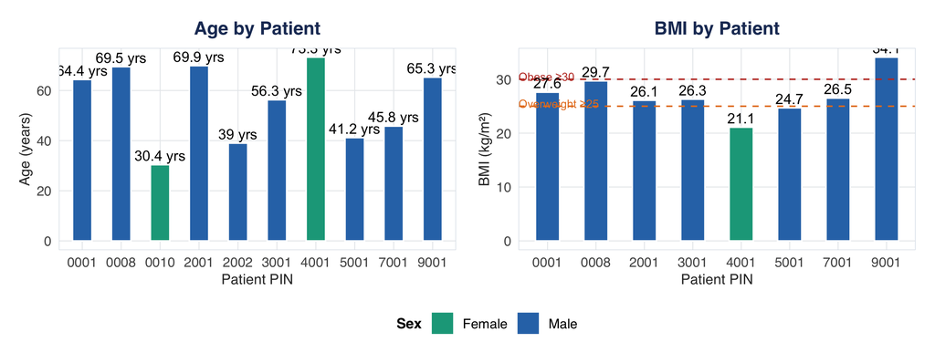

## 1.2 Age–Sex Pyramid

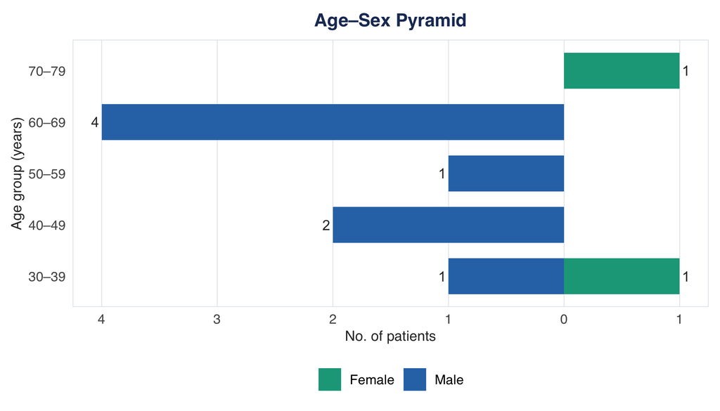

# 2. Exposure History

**Exposure History — Prior 14 Days**

| Exposure | 0001 | 0008 | 0010 | 2001 | 2002 | 3001 | 4001 | 5001 | 7001 | 9001 |
| --- | --- | --- | --- | --- | --- | --- | --- | --- | --- | --- |
| Contact with animals/products | No | Unknown | Unknown | No | No | No | No | Unknown | No | No |
| Contact with confirmed/suspected case | Yes | Yes | Yes | No | Yes | Yes | No | Yes | Yes | Yes |
| Flood / stagnant water exposure | No | Unknown | No | No | No | No | No | Unknown | No | No |
| Rodent sighting on vessel | No | No | Unknown | No | No | No | No | No | No | No |
| Rodent-contaminated environment | No | Yes | No | No | No | No | No | No | No | No |
| Swimming / bathing in natural water | No | Unknown | No | No | No | No | No | Yes | No | No |
| Travel outside home region | Yes | Yes | Yes | Yes | Yes | Yes | Yes | Yes | Yes | Yes |

# 3. Comorbidities

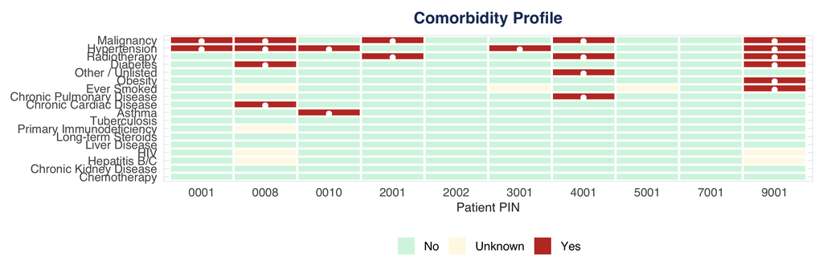

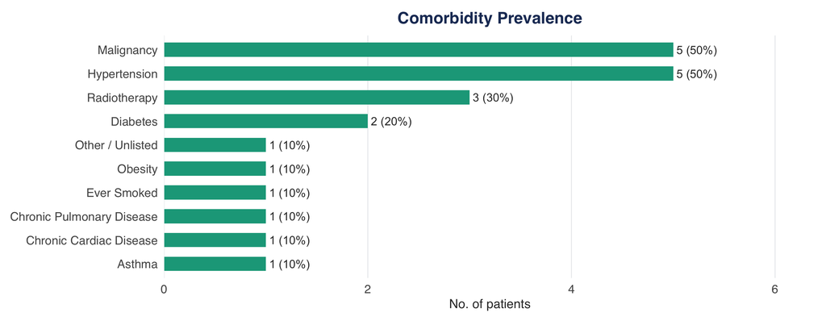

# 4. Symptoms at Admission

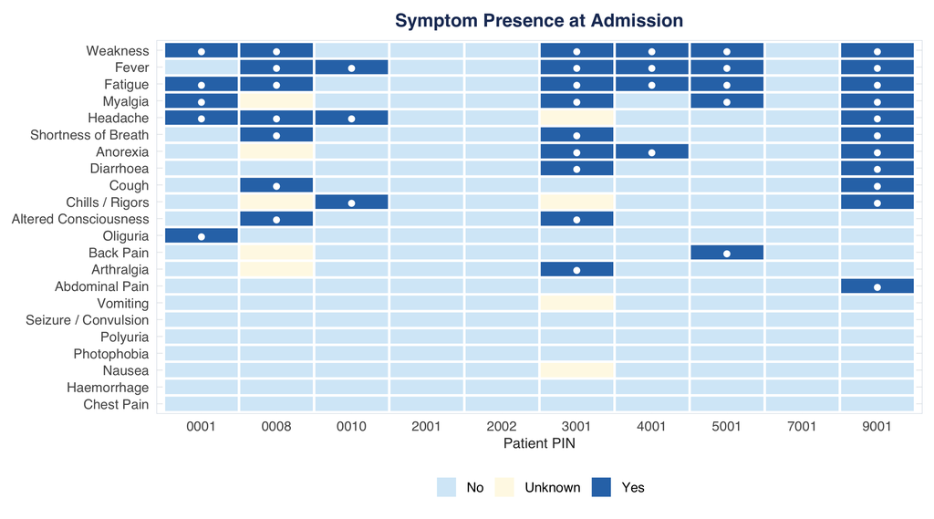

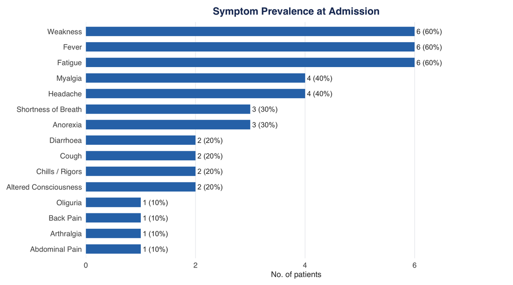

# 5. Daily Monitoring — Vitals & Laboratory Values

## 5.1 Vital Signs Over Time

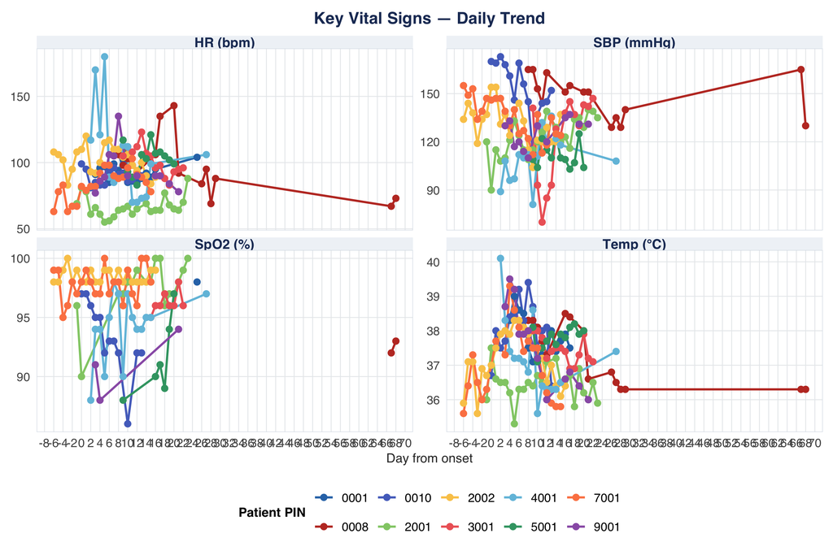

| pin | date | day_from_onset | Temp (°C) | HR (bpm) | RR (/min) | SBP (mmHg) | DBP (mmHg) | SpO2 (%) | GCS | Urine (mL/day) |
| --- | --- | --- | --- | --- | --- | --- | --- | --- | --- | --- |
| 0001 | 2026-05-04 | 3 | 38 | 91 |  |  |  |  | 15 |  |
| 0001 | 2026-05-05 | 4 | 38.3 | 96 |  |  |  |  | 15 |  |
| 0001 | 2026-05-06 | 5 | 39 | 97 |  |  |  |  | 15 |  |
| 0001 | 2026-05-07 | 6 | 38.6 | 85 |  |  |  |  | 15 |  |
| 0001 | 2026-05-08 | 7 | 38.5 | 99 |  |  |  |  | 15 |  |
| 0001 | 2026-05-09 | 8 | 37.5 | 94 |  |  |  |  |  |  |
| 0001 | 2026-05-10 | 9 | 37.1 | 102 |  |  |  |  | 15 |  |
| 0001 | 2026-05-11 | 10 | 37.2 | 85 |  |  |  |  |  |  |
| 0001 | 2026-05-12 | 11 | 37.3 | 86 |  |  |  |  | 15 |  |
| 0001 | 2026-05-13 | 12 | 37.3 | 85 |  |  |  |  | 15 |  |

[output cut: 162 more lines]

## 5.2 Key Laboratory Parameters

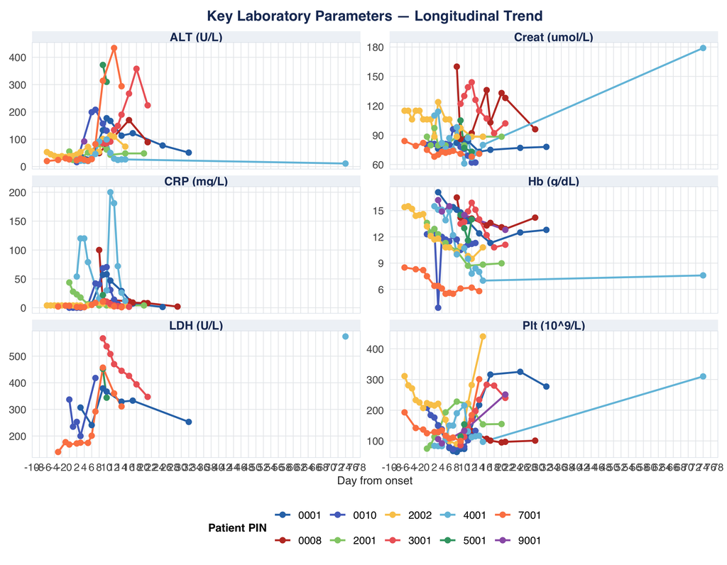

| pin | date | day_from_onset | Hb (g/dL) | WBC (10^9/L) | Neut (10^9/L) | Lymph (10^9/L) | Eosino (10^9/L) | Plt (10^9/L) | Hct (%) | MCV (fL) | MCH (pg) | MCHC (g/dL) | PT (s) | APTT (s) | APTR | INR | ALT (U/L) | AST (U/L) | ALP (U/L) | GGT (U/L) | D-dimer (mg/L) | CRP (mg/L) | Ferritin (ug/L) | Glucose (mmol/L) | BUN (mmol/L) | Creat (umol/L) | Na (mmol/L) | K (mmol/L) | LDH (U/L) | … |
| --- | --- | --- | --- | --- | --- | --- | --- | --- | --- | --- | --- | --- | --- | --- | --- | --- | --- | --- | --- | --- | --- | --- | --- | --- | --- | --- | --- | --- | --- | --- |
| 0001 | 2026-05-04 | 3 | 17.1 | 4.63 | 3.07 | 0.85 | 0.05 | 151 | 50 |  |  |  |  |  |  |  | 40 | 41 |  |  |  | 1.4 |  |  |  | 76 | 135 | 3.6 | 307 | … |
| 0001 | 2026-05-05 | 4 |  |  |  |  |  |  |  |  |  |  |  |  |  |  |  |  |  |  |  |  |  |  |  |  |  |  |  | … |
| 0001 | 2026-05-06 | 5 |  |  |  |  |  |  |  |  |  |  |  |  |  |  |  |  |  |  |  |  |  |  |  |  |  |  |  | … |
| 0001 | 2026-05-07 | 6 | 15.4 | 4.99 |  | 0.76 | 0 | 77 | 44.2 |  |  |  |  |  |  |  | 29 | 37 |  | 28 |  | 5.9 |  |  |  |  | 131 | 3.5 | 241 | … |
| 0001 | 2026-05-08 | 7 | 15.4 | 5.83 | 4.5 | 0.78 | 0.01 | 67 | 42.8 |  |  |  |  |  |  |  |  |  |  |  |  |  |  |  |  |  | 133 | 3.2 |  | … |
| 0001 | 2026-05-09 | 8 | 15.1 | 5.65 | 4.28 | 0.9 | 0.04 | 64 | 42.8 |  |  |  |  |  |  |  |  |  |  |  |  |  |  |  |  | 82 | 133 |  |  | … |
| 0001 | 2026-05-10 | 9 | 14.8 | 5.57 | 3.99 | 0.95 | 0.08 | 74 | 41.4 |  |  |  |  |  |  |  | 133 | 181 | 90 | 57 |  | 57 | 3169 |  |  |  | 133 | 3.6 | 379 | … |
| 0001 | 2026-05-11 | 10 | 14.2 | 5.83 | 4.04 | 1.11 | 0.1 | 74 | 39.90000000000001 |  |  |  |  |  |  |  | 177 | 220 |  | 79 |  | 58 | 2888 |  |  | 84 | 131 | 3.8 | 367 | … |
| 0001 | 2026-05-12 | 11 | 13.8 | 6.62 | 4.72 | 1.01 | 0.17 | 110 | 39.90000000000001 |  |  |  |  |  |  |  | 167 | 166 | 100 | 93 |  | 47 | 1887 |  |  | 84 | 133 | 3.9 |  | … |
| 0001 | 2026-05-13 | 12 |  |  |  |  |  |  |  |  |  |  |  |  |  |  |  |  |  |  |  |  |  |  |  |  |  |  |  | … |

[output cut: 162 more lines]

# 6. Pathogen Testing

**Pathogen Test Results Summary**

| Result | N | % |
| --- | --- | --- |
| Negative | 1 | 0.3% |
| Pending/Unknown | 98 | 25.5% |
| Positive | 286 | 74.3% |

| PIN | Collection Date | Specimen | Pathogen | Method | PCR Method | Result | CT Value | Viral Load | Genotyped |
| --- | --- | --- | --- | --- | --- | --- | --- | --- | --- |
| 0001 | 2026-05-04 | Whole Blood | Other | PCR (NAAT) |  | Positive | 20.5 |  | Yes |
| 0001 | 2026-05-04 | Urine | Other | PCR (NAAT) |  | Positive | 33.9 |  | No |
| 0001 | 2026-05-04 | NP / Respiratory Swab | Other | PCR (NAAT) |  | Positive | 31.8 |  | No |
| 0001 | 2026-05-08 | Whole Blood | Other | PCR (NAAT) |  | Positive | 22.7 |  | No |
| 0001 | 2026-05-12 | Whole Blood | Other | PCR (NAAT) |  | Positive | 25.7 |  | No |
| 0001 | 2026-05-12 | Urine | Other | PCR (NAAT) |  | Positive | 35.5 |  | No |
| 0001 | 2026-05-12 | NP / Respiratory Swab | Other | PCR (NAAT) |  | Positive | 31.7 |  | No |
| 0001 | 2026-05-15 | Whole Blood | Other | PCR (NAAT) |  | Positive | 26.2 |  | No |
| 0001 | 2026-05-15 | Urine | Other | PCR (NAAT) |  | Positive | 33.9 |  | No |
| 0001 | 2026-05-15 | NP / Respiratory Swab | Other | PCR (NAAT) |  | Positive | 34.9 |  | No |

[output cut: 375 more lines]

## 6.1 Ct Value Trajectories by Specimen Type

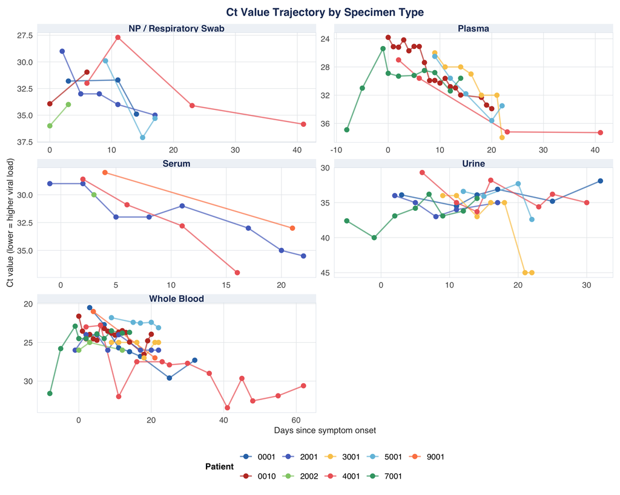

# 7. Respiratory Support

## 7.1 Respiratory Support Prevalence

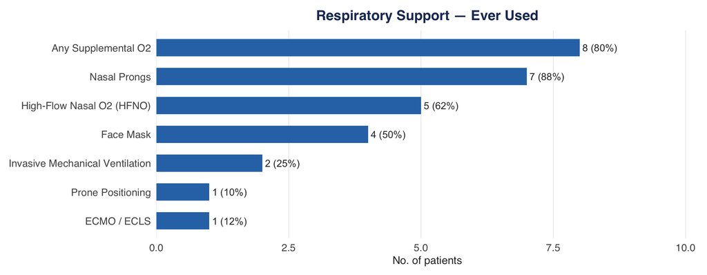

## 7.2 Respiratory Support by Patient (Heatmap)

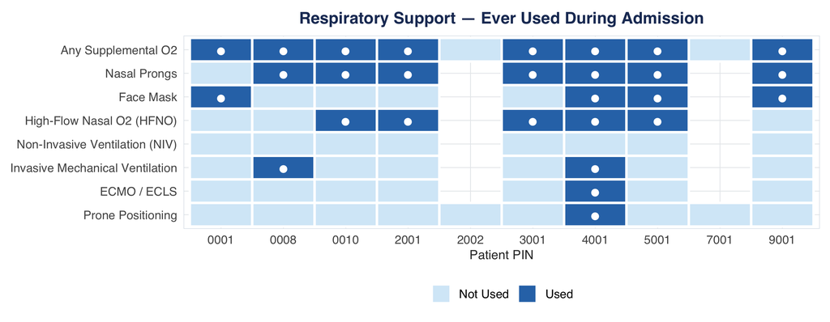

## 7.3 NIV, ECMO & Prone Detail

> No NIV episodes recorded.

**ECMO episodes:**

**ECMO Episodes**

| PIN | Date | ECMO_Type |
| --- | --- | --- |
| 4001 | 2026-05-18 | Veno-venous (VV) |
| 4001 | 2026-05-19 | Veno-venous (VV) |
| 4001 | 2026-05-20 | Veno-venous (VV) |
| 4001 | 2026-05-21 | Veno-venous (VV) |
| 4001 | 2026-05-22 | Veno-venous (VV) |
| 4001 | 2026-05-23 | Veno-venous (VV) |

**Prone positioning:**

**Prone Positioning**

| PIN | Date | Prone_When |
| --- | --- | --- |
| 4001 | 2026-05-12 | During invasive ventilation |
| 4001 | 2026-05-13 | During invasive ventilation |
| 4001 | 2026-05-15 | During invasive ventilation |
| 4001 | 2026-05-16 | During invasive ventilation |
| 4001 | 2026-05-17 | NA |

# 8. Treatment — Fluids & Blood Products

## 8.1 Fluid & Blood Product Prevalence

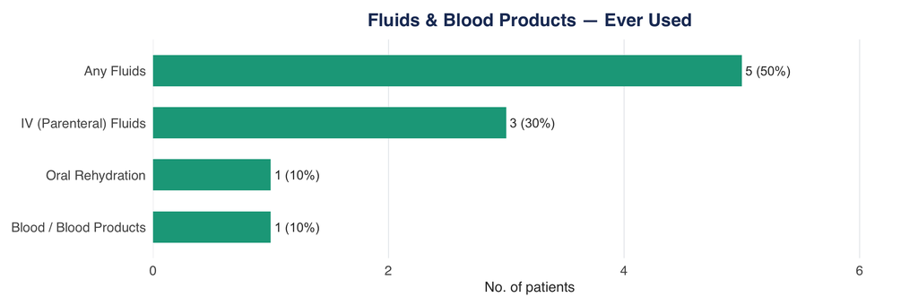

## 8.2 Blood Product Transfusions

**Blood Product Transfusions**

| PIN | Date | Blood Products |
| --- | --- | --- |
| 4001 | 2026-05-18 | Packed RBC |
| 4001 | 2026-05-19 | Packed RBC |
| 4001 | 2026-06-04 | Packed RBC |

# 9. Medications — Antivirals, MAb & Other Therapies

This section covers all medications prescribed during hospitalisation, with particular focus on **antiviral agents** (Ribavirin, Favipiravir) and **monoclonal antibodies / immunosuppressants**.

## 9.1 Medication Frequency by Type

**Medications by Type — All Courses**

| Medication Type | N Courses | % |
| --- | --- | --- |
| Other | 23 | 33.8% |
| Antiviral | 11 | 16.2% |
| Anticoagulant | 9 | 13.2% |
| Analgesic | 7 | 10.3% |
| Antibiotic | 7 | 10.3% |
| Corticosteroid | 5 | 7.4% |
| Immunosuppressant | 3 | 4.4% |
| Inotrope/Vasopressor | 3 | 4.4% |

## 9.2 Antiviral Agents

**Antiviral Agents**

Including Ribavirin, Favipiravir, and other antivirals

| PIN | Agent | Purpose | Route | Start | End | Days | Dose | Units | Off-label | Off-label spec |
| --- | --- | --- | --- | --- | --- | --- | --- | --- | --- | --- |
| 0001 | Ribavirin | Not specified | Oral | NA | NA | NA | NA | NA | Yes | Off-label |
| 0010 | Other | Treatment | IV | 2026-05-16 | 2026-05-16 | NA | 200 | mg | Yes | remdesivir |
| 0010 | Favipiravir | Treatment | Oral | 2026-05-19 | 2026-05-22 | 4 | 1400 | mg | Yes | Favipiravir |
| 0010 | Favipiravir | Treatment | IV | 2026-05-22 | 2026-05-29 | 7 | 1800 | mg | Yes | favipiravir |
| 2001 | Ribavirin | Treatment | IV | 2026-05-12 | 2026-05-17 | 6 | 1 | g | Yes | Off-label |
| 2001 | Favipiravir | Treatment | Oral | 2026-05-12 | 2026-05-21 | 9 | 1200 | mg | Yes | Off-label |
| 2002 | Favipiravir | Treatment | Oral | 2026-05-25 | 2026-06-08 | 14 | 1400 | mg | Yes | Off-label |
| 2002 | Ribavirin | Treatment | IV | 2026-05-25 | 2026-06-01 | 7 | 1 | g | Yes | Off-label |
| 4001 | Favipiravir | Treatment | IV | 2026-05-12 | 2026-05-30 | 14 | 1400 | mg | Yes | compassionate |
| 7001 | Ribavirin | Treatment | IV | 2026-05-21 | 2026-05-24 | 3 | 1400 | mg | Yes | ribavirin |
| 7001 | Ribavirin | Treatment | Oral | 2026-05-24 | 2026-05-31 | 7 | 1000 | mg | Yes | Ribavirin |

## 9.3 Monoclonal Antibodies & Immunosuppressants

**Monoclonal Antibodies & Immunosuppressants**

Including Rituximab, IVIG, and other MAb / immunosuppressive agents

| PIN | Type | Agent | Purpose | Route | Start | End | Days | Dose | Units | Off-label | Off-label spec |
| --- | --- | --- | --- | --- | --- | --- | --- | --- | --- | --- | --- |
| 2001 | Immunosuppressant | Baricitinib | Treatment | Oral | 2026-05-13 | 2026-05-22 | 10 | 4 | mg | Yes | Off-label |
| 3001 | Immunosuppressant | Other MAb/Immunosupp | Treatment | IV | 2026-05-06 | 2026-05-07 | 1 | 600 | mg | Yes | tocilizumab is registered for autoimmune diseases. Used as immunomodulatory treatment in viral infections, previously in COVID for example. |
| 5001 | Immunosuppressant | Other MAb/Immunosupp | Treatment | IV | 2026-05-07 | 2026-05-07 | 1 | 800 | mg | Yes | for hante HCPS |

## 9.4 Corticosteroids

**Corticosteroids**

| PIN | Agent | Purpose | Route | Start | End | Days | Dose | Units |
| --- | --- | --- | --- | --- | --- | --- | --- | --- |
| 0010 | Dexamethasone | Treatment | IV | 2026-05-23 | 2026-05-27 | 5 | 6 | mg |
| 3001 | Dexamethasone | Not specified | IV | NA | NA | NA | NA | NA |
| 4001 | Hydrocortisone | Treatment | IV | 2026-05-11 | 2026-05-22 | 10 | 50 | mg |
| 5001 | Dexamethasone | Treatment | IV | 2026-05-07 | 2026-05-12 | 6 | 6 | mg |
| 9001 | Dexamethasone | Not specified | IV | NA | NA | NA | NA | NA |

## 9.5 Anticoagulation

**Anticoagulants**

| PIN | Agent | Indication | Route | Start | End | Days | Dose | Units |
| --- | --- | --- | --- | --- | --- | --- | --- | --- |
| 0008 | Enoxaparin | Routine inpatient prophylaxis | Subcutaneous | NA | NA | NA | NA | NA |
| 0010 | Enoxaparin | Routine inpatient prophylaxis | Subcutaneous | NA | NA | NA | NA | NA |
| 2001 | Enoxaparin | Routine inpatient prophylaxis | Subcutaneous | NA | NA | NA | NA | NA |
| 2002 | Enoxaparin | Routine inpatient prophylaxis | Subcutaneous | NA | NA | NA | NA | NA |
| 2002 | Other | Routine inpatient prophylaxis | Subcutaneous | NA | NA | NA | NA | NA |
| 3001 | Other | Routine inpatient prophylaxis | Subcutaneous | NA | NA | NA | NA | NA |
| 4001 | Heparin | Routine inpatient prophylaxis | Subcutaneous | 2026-05-11 | 2026-05-19 | NA | NA | NA |
| 4001 | Heparin | Therapeutic (DVT/PE) | Subcutaneous | 2026-05-19 | NA | NA | NA | NA |
| 7001 | Enoxaparin | Routine inpatient prophylaxis | Subcutaneous | NA | NA | NA | NA | NA |

## 9.6 Complete Medication Log

| PIN | Type | Agent | Route | Start | End | Days | Dose | Units | Purpose | Off-label |
| --- | --- | --- | --- | --- | --- | --- | --- | --- | --- | --- |
| 0001 | Antiviral | Ribavirin | Oral |  |  |  |  |  |  | Yes |
| 0008 | Antibiotic | Other |  | 2026-05-01 | 2026-05-05 | 5 | 500 | mg | Treatment | No |
| 0008 | Anticoagulant | Enoxaparin | Subcutaneous |  |  |  |  |  |  | No |
| 0008 | Analgesic |  | IV |  |  |  |  |  |  | No |
| 0008 | Other |  |  |  |  |  |  |  |  | No |
| 0008 | Analgesic |  | IV |  |  |  |  |  |  | No |
| 0008 | Other |  |  |  |  |  |  |  |  | No |
| 0008 | Inotrope/Vasopressor |  |  |  |  |  |  |  |  | No |
| 0008 | Other |  |  |  |  |  |  |  |  | No |
| 0008 | Inotrope/Vasopressor |  |  |  |  |  |  |  |  | No |

[output cut: 58 more lines]

# 10. Advanced Care Interventions

## 10.1 Advanced Care Prevalence

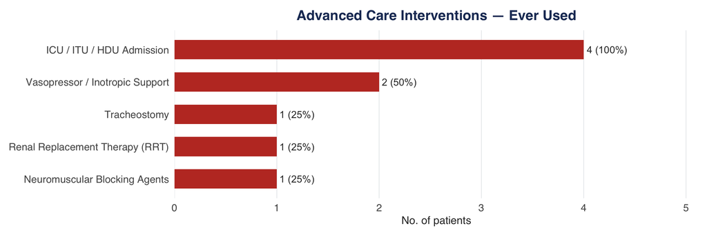

## 10.2 Vasopressor / Inotrope Detail

**Vasopressor / Inotrope Use**

| PIN | Date | Reason |
| --- | --- | --- |
| 0008 | Apr 30, 2026 | Not specified |
| 4001 | May 10, 2026 | Not specified |
| 4001 | May 11, 2026 | Not specified |
| 4001 | May 12, 2026 | Not specified |
| 4001 | May 13, 2026 | Not specified |
| 4001 | May 18, 2026 | Not specified |
| 4001 | May 19, 2026 | Not specified |

## 10.3 Renal Replacement Therapy (RRT)

**Renal Replacement Therapy**

| PIN | Date | RRT Type |
| --- | --- | --- |
| 4001 | Jun 10, 2026 | Continuous |
| 4001 | Jul 21, 2026 | Intermittent |

# 11. Diagnosis & Outcomes

## 11.1 Primary Diagnosis

**Primary Diagnosis**

| PIN | Primary Diagnosis | Diagnosis Type |
| --- | --- | --- |
| 0001 | Andes virus (hantavirus) | Lab-confirmed |
| 0008 | Andes virus (hantavirus) | Lab-confirmed |
| 0010 | Andes virus (hantavirus) | Lab-confirmed |
| 2001 | Andes virus (hantavirus) | Lab-confirmed |
| 2002 | Andes virus (hantavirus) | Lab-confirmed |
| 3001 | Andes virus (hantavirus) | Lab-confirmed |
| 4001 | Andes virus (hantavirus) | Lab-confirmed |
| 5001 | Andes virus (hantavirus) | Lab-confirmed |
| 7001 | Andes virus (hantavirus) | Lab-confirmed |
| 9001 | Andes virus (hantavirus) | Lab-confirmed |

## 11.2 Outcomes

**Patient Outcomes**

| PIN | Outcome | Outcome Date | O2 at Discharge | Self-care | Ongoing Care |
| --- | --- | --- | --- | --- | --- |
| 0001 | Discharged alive | May 18, 2026 | No | Same as before | No |
| 0008 | Discharged alive | Jul 1, 2026 | No | Same as before | No |
| 0010 | Discharged alive | Jun 4, 2026 | No | Worse | Yes |
| 2001 | Discharged alive | Jun 4, 2026 | No | Same as before | Yes |
| 2002 | Discharged alive | Jun 16, 2026 | No | Same as before | No |
| 3001 | Discharged alive | May 23, 2026 | No | Same as before | No |
| 4001 | Discharged alive | Aug 6, 2026 | NA | NA | Yes |
| 5001 | Discharged alive | May 20, 2026 | No | Same as before | No |
| 7001 | Discharged alive | Jun 11, 2026 | No | Same as before | Yes |
| 9001 | Discharged alive | May 20, 2026 | No | Same as before | No |

## 11.3 Outcome Distribution

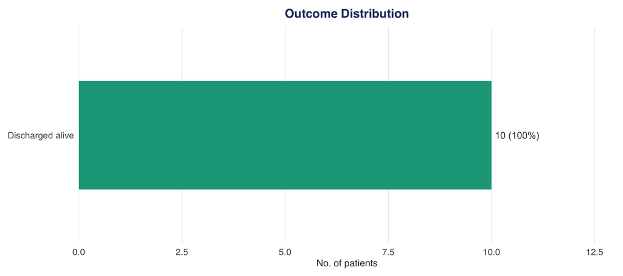

# 12. Complications

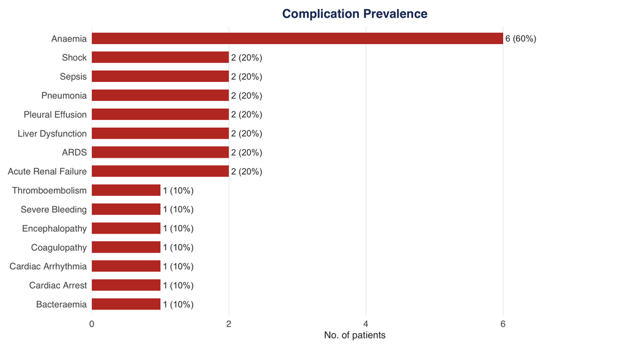

# 13. Individual Patient Profiles

## Patient 0001

**Sex:** Male | **Age:** 64.4 yrs | **BMI:** 27.6 kg/m² | **Admitted:** Yes | **HCW:** No

**Onset:** 01 May 2026 | **First consultation:** 04 May 2026 | **Admission:** 04 May 2026

**Symptoms at admission:** Fatigue, Weakness, Myalgia, Oliguria, Headache

**Comorbidities:** Hypertension, Malignancy

**Exposure history:** Travel outside home region, Contact with confirmed/suspected case *(Travel: Argentina (Buenos Aires, Rio Grande, Ushuaia); MS Hondius Cruise Ship)*

**Complications:** *None recorded*

**Day 1 Laboratory Results** *(date: 04 May 2026)*

**Day 1 Labs**

| Parameter | Value |
| --- | --- |
| Hb (g/dL) | 17.10 |
| WBC (10^9/L) | 4.63 |
| Neut (10^9/L) | 3.07 |
| Lymph (10^9/L) | 0.85 |
| Eosino (10^9/L) | 0.05 |
| Plt (10^9/L) | 151.00 |
| Hct (%) | 50.00 |
| ALT (U/L) | 40.00 |
| AST (U/L) | 41.00 |
| CRP (mg/L) | 1.40 |
| Creat (umol/L) | 76.00 |
| Na (mmol/L) | 135.00 |
| K (mmol/L) | 3.60 |
| LDH (U/L) | 307.00 |

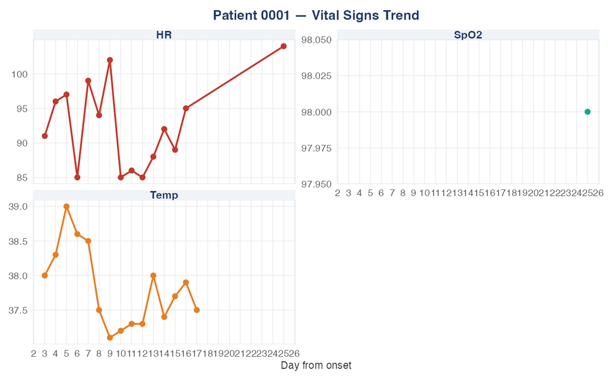

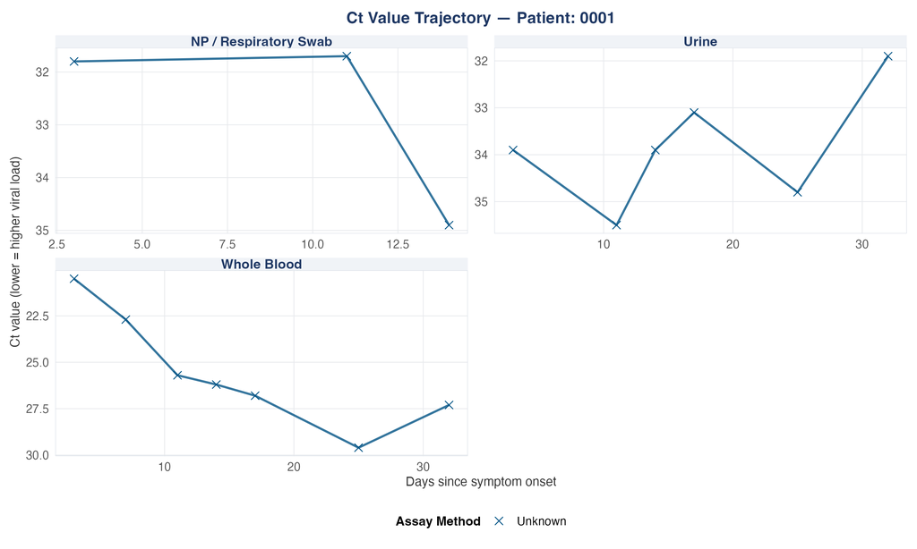

**Respiratory support used:** Supplemental O2, Face Mask

**Medications:** Ribavirin (Antiviral)

**Outcome:** Discharged alive | 18 May 2026 | Self-care: Same as before

## Patient 0008

**Sex:** Male | **Age:** 69.5 yrs | **BMI:** 29.7 kg/m² | **Admitted:** Yes | **HCW:** No

**Onset:** 22 Apr 2026 | **First consultation:** 25 Apr 2026 | **Admission:** 30 Apr 2026

**Symptoms at admission:** Fever, Fatigue, Weakness, Cough, Shortness of Breath, Headache, Altered Consciousness

**Comorbidities:** Chronic Cardiac Disease, Hypertension, Diabetes, Malignancy

**Exposure history:** Travel outside home region, Contact with confirmed/suspected case, Rodent-contaminated environment *(Travel: Agentina and Chile since March 18th)*

**Complications:** Pneumonia, ARDS, Bacteraemia, Shock, Sepsis

**Day 1 Laboratory Results** *(date: 30 Apr 2026)*

**Day 1 Labs**

| Parameter | Value |
| --- | --- |
| Hb (g/dL) | 16.50 |
| WBC (10^9/L) | 13.07 |
| Neut (10^9/L) | 9.70 |
| Lymph (10^9/L) | 2.07 |
| Eosino (10^9/L) | 0.10 |
| Plt (10^9/L) | 84.00 |
| Hct (%) | 41.60 |
| MCV (fL) | 92.40 |
| MCH (pg) | 30.40 |
| MCHC (g/dL) | 3.29 |
| ALT (U/L) | 49.00 |
| AST (U/L) | 86.00 |
| ALP (U/L) | 45.00 |
| GGT (U/L) | 75.00 |
| CRP (mg/L) | 100.00 |
| Glucose (mmol/L) | 20.50 |
| BUN (mmol/L) | 9.00 |
| Creat (umol/L) | 160.00 |
| Na (mmol/L) | 137.00 |
| K (mmol/L) | 3.50 |
| pH | 7.42 |
| HCO3 (mmol/L) | 23.10 |
| Base Excess | −2.00 |

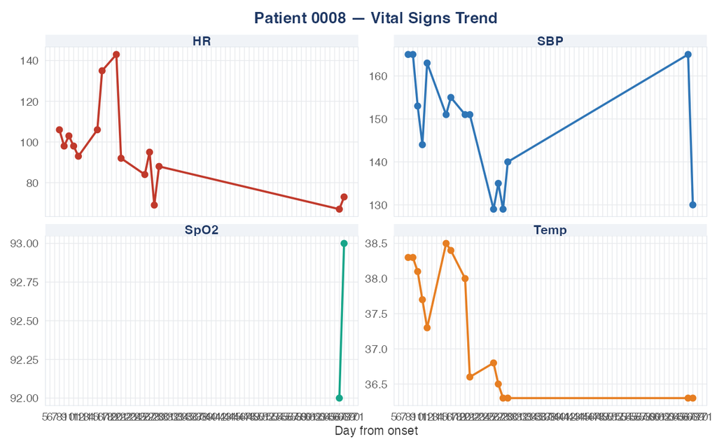

**Respiratory support used:** Supplemental O2, Nasal Prongs, Invasive Ventilation

**Medications:** Enoxaparin (Anticoagulant); Other (Antibiotic)

**Outcome:** Discharged alive | 01 Jul 2026 | Self-care: Same as before

## Patient 0010

**Sex:** Female | **Age:** 30.4 yrs | **BMI:** N/A kg/m² | **Admitted:** Yes | **HCW:** No

**Onset:** 14 May 2026 | **First consultation:** 14 May 2026 | **Admission:** 14 May 2026

**Symptoms at admission:** Fever, Chills / Rigors, Headache

**Comorbidities:** Hypertension, Asthma

**Exposure history:** Travel outside home region, Contact with confirmed/suspected case *(Travel: Ushuaia, Argentina Antarctica Canary Islands)*

**Complications:** Liver Dysfunction, Anaemia

**Day 1 Laboratory Results** *(date: 14 May 2026)*

**Day 1 Labs**

| Parameter | Value |
| --- | --- |
| Hb (g/dL) | 12.30 |
| WBC (10^9/L) | 3.86 |
| Neut (10^9/L) | 4.77 |
| Lymph (10^9/L) | 0.43 |
| Eosino (10^9/L) | 0.11 |
| Plt (10^9/L) | 208.00 |
| Hct (%) | 38.00 |
| MCV (fL) | 97.00 |
| CRP (mg/L) | 0.00 |
| Glucose (mmol/L) | 4.40 |
| Creat (umol/L) | 80.00 |
| Na (mmol/L) | 138.00 |
| K (mmol/L) | 4.10 |
| LDH (U/L) | 337.00 |

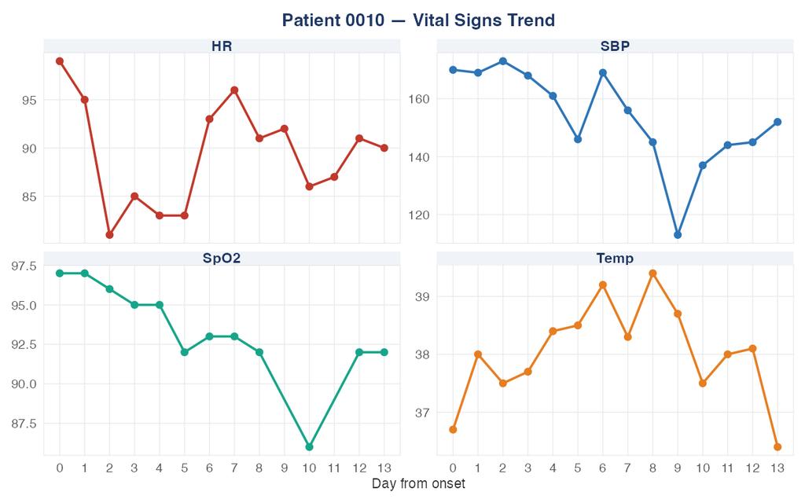

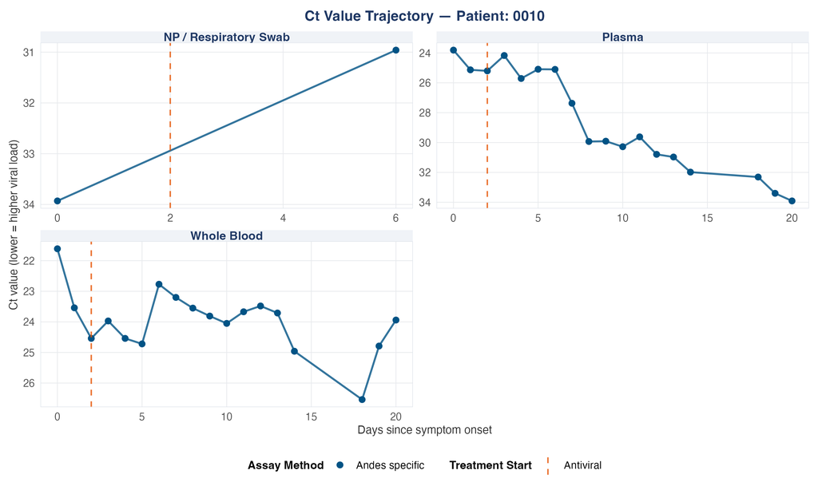

**Respiratory support used:** Supplemental O2, Nasal Prongs, HFNO

**Medications:** Favipiravir (Antiviral); Favipiravir (Antiviral); Other (Antiviral); Dexamethasone (Corticosteroid); Enoxaparin (Anticoagulant)

**Outcome:** Discharged alive | 04 Jun 2026 | Self-care: Worse

## Patient 2001

**Sex:** Male | **Age:** 69.9 yrs | **BMI:** 26.1 kg/m² | **Admitted:** Yes | **HCW:** No

**Onset:** 12 May 2026 | **First consultation:** 11 May 2026 | **Admission:** 11 May 2026

**Symptoms at admission:** *None recorded*

**Comorbidities:** Malignancy, Radiotherapy

**Exposure history:** Travel outside home region *(Travel: Argentina, South Georgia, Tristan da Cunha, Santa Helena (all during MV Hondius trip).)*

**Complications:** Pleural Effusion, Anaemia

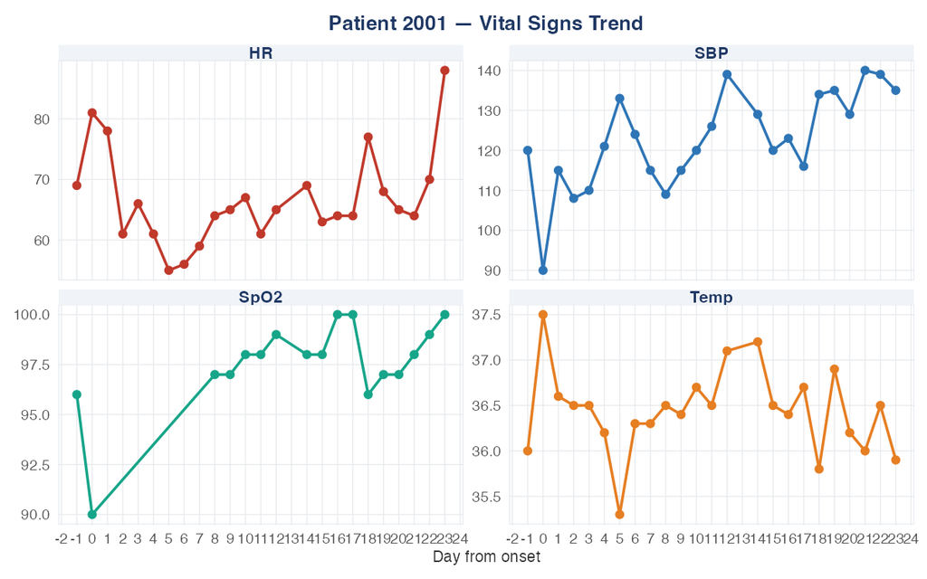

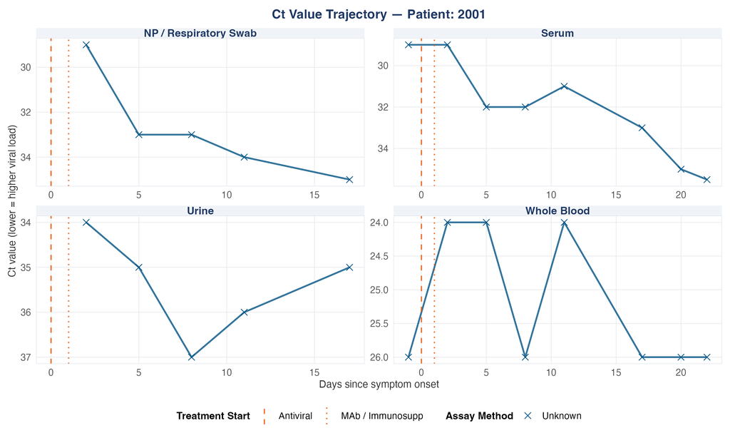

**Respiratory support used:** Supplemental O2, Nasal Prongs, HFNO

**Medications:** Ribavirin (Antiviral); Favipiravir (Antiviral); Baricitinib (Immunosuppressant); Enoxaparin (Anticoagulant)

**Outcome:** Discharged alive | 04 Jun 2026 | Self-care: Same as before

## Patient 2002

**Sex:** Male | **Age:** 39 yrs | **BMI:** N/A kg/m² | **Admitted:** Yes | **HCW:** No

**Onset:** 31 May 2026 | **First consultation:** 10 May 2026 | **Admission:** 10 May 2026

**Symptoms at admission:** *None recorded*

**Comorbidities:** *None recorded*

**Exposure history:** Travel outside home region, Contact with confirmed/suspected case *(Travel: Argentina, South Georgia, Tristan da Cunha, Santa Helena (all during MV Hondius trip).)*

**Complications:** Anaemia

**Day 1 Laboratory Results** *(date: 25 May 2026)*

**Day 1 Labs**

| Parameter | Value |
| --- | --- |
| Hb (g/dL) | 15.40 |
| WBC (10^9/L) | 11.00 |
| Neut (10^9/L) | 8.80 |
| Lymph (10^9/L) | 1.50 |
| Eosino (10^9/L) | 0.13 |
| Plt (10^9/L) | 311.00 |
| Hct (%) | 43.80 |
| MCV (fL) | 88.60 |
| MCH (pg) | 31.20 |
| MCHC (g/dL) | 35.20 |
| INR | 1.10 |
| ALT (U/L) | 53.00 |
| AST (U/L) | 30.00 |
| CRP (mg/L) | 4.00 |
| Glucose (mmol/L) | 5.66 |
| BUN (mmol/L) | 5.33 |
| Creat (umol/L) | 114.92 |
| Na (mmol/L) | 133.00 |
| K (mmol/L) | 4.10 |
| pH | 7.44 |
| HCO3 (mmol/L) | 23.70 |
| Base Excess | −1.00 |

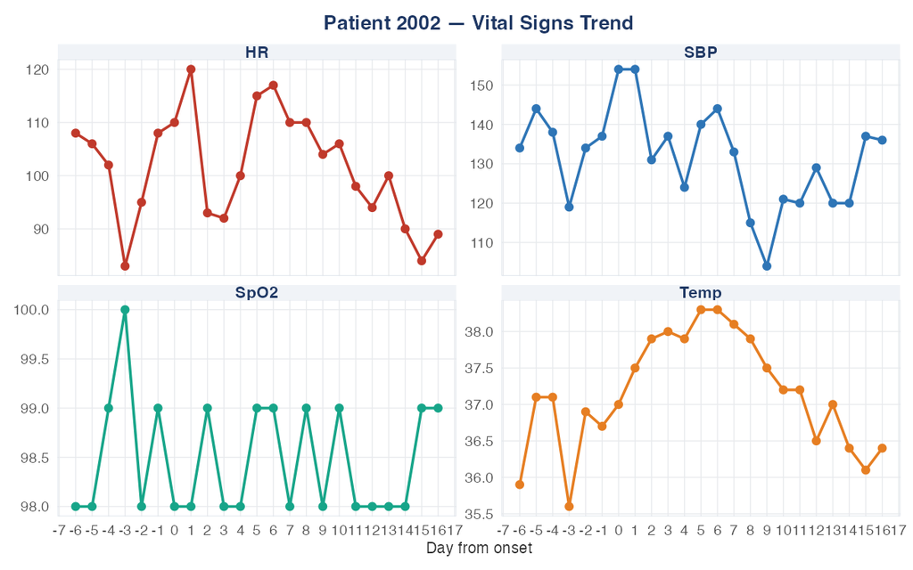

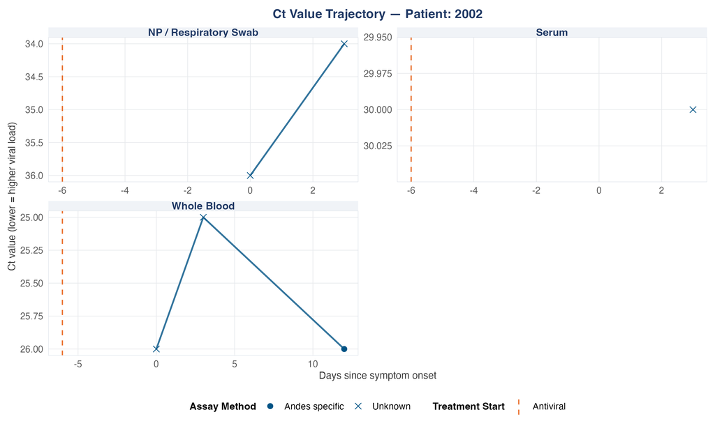

**Respiratory support used:** *None recorded*

**Medications:** Favipiravir (Antiviral); Ribavirin (Antiviral); Enoxaparin (Anticoagulant); Other (Anticoagulant); Other (Antibiotic)

**Outcome:** Discharged alive | 16 Jun 2026 | Self-care: Same as before

## Patient 3001

**Sex:** Male | **Age:** 56.3 yrs | **BMI:** 26.3 kg/m² | **Admitted:** Yes | **HCW:** No

**Onset:** 27 Apr 2026 | **First consultation:** NA | **Admission:** 06 May 2026

**Symptoms at admission:** Fever, Fatigue, Weakness, Myalgia, Arthralgia, Shortness of Breath, Diarrhoea, Anorexia, Altered Consciousness

**Comorbidities:** Hypertension

**Exposure history:** Travel outside home region, Contact with confirmed/suspected case *(Travel: Cruise ship Hondius from 21 March 2026 until 6th May 2026)*

**Complications:** Anaemia, Acute Renal Failure

**Day 1 Laboratory Results** *(date: 06 May 2026)*

**Day 1 Labs**

| Parameter | Value |
| --- | --- |
| Hb (g/dL) | 13.50 |
| WBC (10^9/L) | 6.92 |
| Neut (10^9/L) | 5.31 |
| Lymph (10^9/L) | 1.17 |
| Eosino (10^9/L) | 0.01 |
| Plt (10^9/L) | 86.00 |
| Hct (%) | 35.60 |
| MCV (fL) | 78.00 |
| MCH (pg) | 1.85 |
| PT (s) | 16.30 |
| APTT (s) | 49.60 |
| INR | 1.20 |
| ALT (U/L) | 85.00 |
| AST (U/L) | 132.00 |
| ALP (U/L) | 52.00 |
| GGT (U/L) | 79.00 |
| D-dimer (mg/L) | 2.55 |
| CRP (mg/L) | 13.50 |
| Ferritin (ug/L) | 11,182.00 |
| Glucose (mmol/L) | 6.30 |
| BUN (mmol/L) | 9.30 |
| Creat (umol/L) | 122.00 |
| Na (mmol/L) | 122.00 |
| K (mmol/L) | 3.30 |
| LDH (U/L) | 567.00 |
| pH | 7.49 |
| HCO3 (mmol/L) | 23.00 |
| Base Excess | 1.00 |
| IL-6 (pg/mL) | 60.00 |

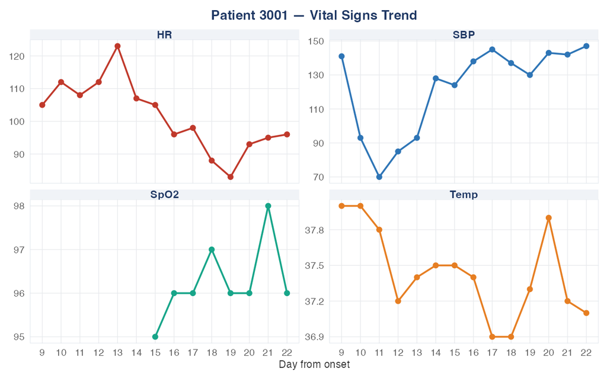

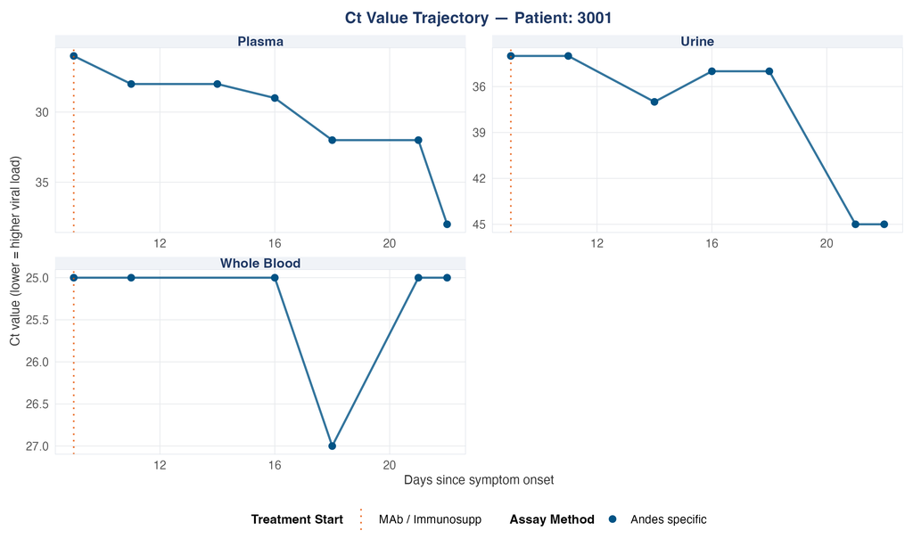

**Respiratory support used:** Supplemental O2, Nasal Prongs, HFNO

**Medications:** Dexamethasone (Corticosteroid); Other MAb/Immunosupp (Immunosuppressant); Ceftriaxone (Antibiotic); Other (Anticoagulant)

**Outcome:** Discharged alive | 23 May 2026 | Self-care: Same as before

## Patient 4001

**Sex:** Female | **Age:** 73.3 yrs | **BMI:** 21.1 kg/m² | **Admitted:** Yes | **HCW:** No

**Onset:** 08 May 2026 | **First consultation:** 10 May 2026 | **Admission:** 10 May 2026

**Symptoms at admission:** Fever, Fatigue, Weakness, Anorexia

**Comorbidities:** Chronic Pulmonary Disease, Malignancy, Radiotherapy, Other / Unlisted

**Exposure history:** Travel outside home region *(Travel: Argentina and Cruise)*

**Complications:** Encephalopathy, Cardiac Arrhythmia, Cardiac Arrest, Pneumonia, Pleural Effusion, ARDS, Liver Dysfunction, Thromboembolism, Severe Bleeding, Anaemia, Coagulopathy, Acute Renal Failure, Shock, Sepsis

**Day 1 Laboratory Results** *(date: 10 May 2026)*

**Day 1 Labs**

| Parameter | Value |
| --- | --- |
| Hb (g/dL) | 15.50 |
| WBC (10^9/L) | 19.20 |
| Neut (10^9/L) | 16.50 |
| Lymph (10^9/L) | 1.10 |
| Plt (10^9/L) | 84.00 |
| Hct (%) | 46.00 |
| MCV (fL) | 92.00 |
| MCH (pg) | 32.80 |
| MCHC (g/dL) | 35.60 |
| INR | 1.00 |
| ALT (U/L) | 25.00 |
| AST (U/L) | 56.00 |
| CRP (mg/L) | 54.00 |
| Glucose (mmol/L) | 4.00 |
| BUN (mmol/L) | 7.40 |
| Creat (umol/L) | 110.00 |
| Na (mmol/L) | 126.00 |
| K (mmol/L) | 3.40 |
| pH | 7.27 |
| HCO3 (mmol/L) | 20.00 |

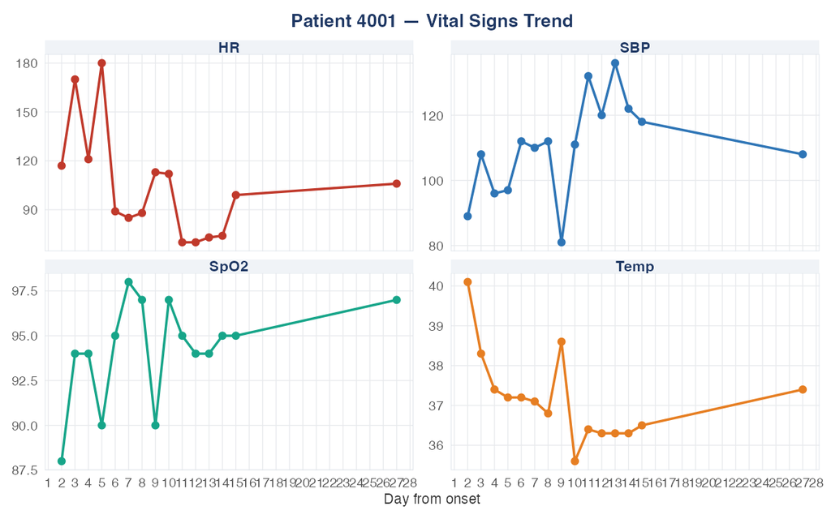

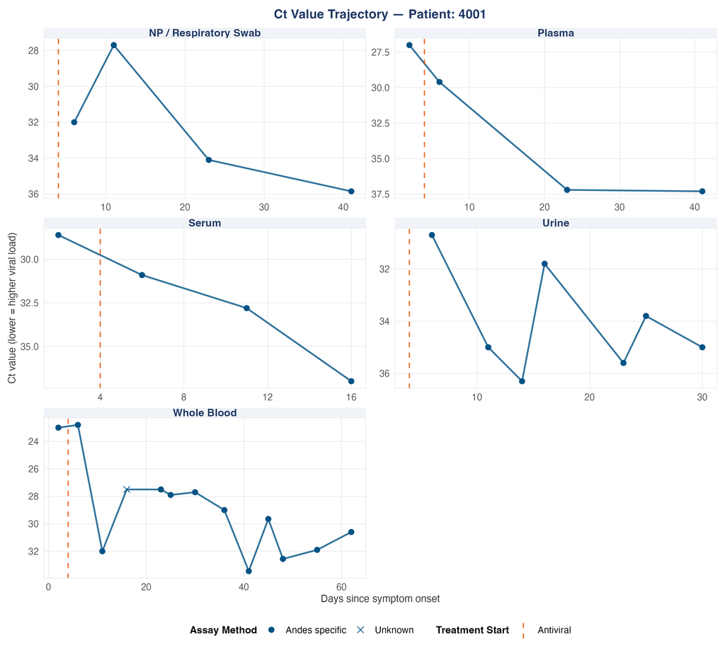

**Respiratory support used:** Supplemental O2, Nasal Prongs, Face Mask, HFNO, Invasive Ventilation, ECMO, Prone Positioning

**Medications:** Favipiravir (Antiviral); Hydrocortisone (Corticosteroid); Ceftriaxone (Antibiotic); Meropenem (Antibiotic); Other (Antibiotic); Heparin (Anticoagulant); Heparin (Anticoagulant)

**Outcome:** Discharged alive | 06 Aug 2026

## Patient 5001

**Sex:** Male | **Age:** 41.2 yrs | **BMI:** 24.7 kg/m² | **Admitted:** Yes | **HCW:** Yes

**Onset:** 28 Apr 2026 | **First consultation:** 07 May 2026 | **Admission:** 07 May 2026

**Symptoms at admission:** Fever, Fatigue, Weakness, Myalgia, Back Pain

**Comorbidities:** *None recorded*

**Exposure history:** Travel outside home region, Contact with confirmed/suspected case, Swimming / bathing in natural water *(Travel: Medical doctor on M/V Hondius)*

**Complications:** *None recorded*

**Day 1 Laboratory Results** *(date: 07 May 2026)*

**Day 1 Labs**

| Parameter | Value |
| --- | --- |
| Hb (g/dL) | 14.50 |
| WBC (10^9/L) | 6.30 |
| Neut (10^9/L) | 4.90 |
| Lymph (10^9/L) | 0.80 |
| Eosino (10^9/L) | 0.10 |
| Plt (10^9/L) | 114.00 |
| PT (s) | 12.70 |
| APTT (s) | 30.00 |
| ALT (U/L) | 372.00 |
| AST (U/L) | 329.00 |
| ALP (U/L) | 75.00 |
| GGT (U/L) | 179.00 |
| D-dimer (mg/L) | 853.00 |
| CRP (mg/L) | 22.00 |
| Ferritin (ug/L) | 3,673.00 |
| Glucose (mmol/L) | 5.70 |
| Creat (umol/L) | 105.00 |
| Na (mmol/L) | 134.00 |
| K (mmol/L) | 3.70 |
| LDH (U/L) | 452.00 |
| pH | 7.44 |
| HCO3 (mmol/L) | 25.30 |

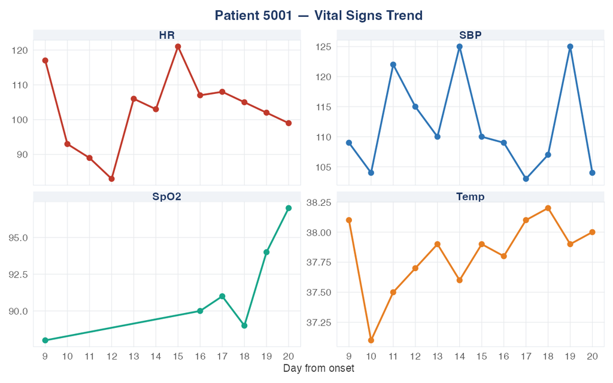

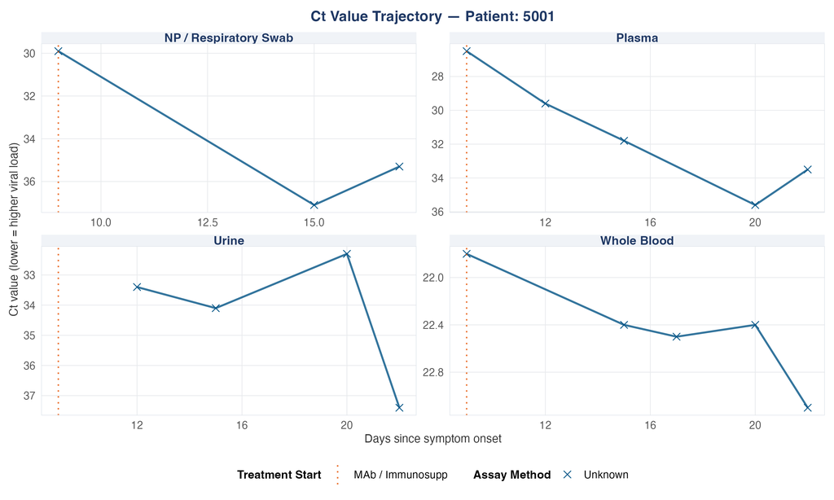

**Respiratory support used:** Supplemental O2, Nasal Prongs, Face Mask, HFNO

**Medications:** Dexamethasone (Corticosteroid); Other MAb/Immunosupp (Immunosuppressant)

**Outcome:** Discharged alive | 20 May 2026 | Self-care: Same as before